# VoiceR Saved Report

This is an automatically generated report by VoiceR.

# Statistics Table

|  | duration | voice_breaks_percent | RMS_env | mean_loudness | mean_F0 | sd_F0 | mean_entropy | mean_HNR | Condition | Dimension | ID |
| --- | --- | --- | --- | --- | --- | --- | --- | --- | --- | --- | --- |
| 1 | 1.187120181405896 | 0.4782608695652174 | 0.117028659137305 | 7.281492421446663 | 197.8740039598297 | 24.2096824401411 | 0.08861176758787684 | 4.244260643109341 | Happy | Bar | d074376d2783eeb959f2f6c02091264c |
| 2 | 1.09453514739229 | 0.1190476190476191 | 0.06534641309649189 | 4.619659334244262 | 168.7127174742614 | 13.70609284362559 | 0.1033255573500632 | 7.431305808581741 | Sad | Bar | d074376d2783eeb959f2f6c02091264c |
| 3 | 1.000453514739229 | 0.5641025641025641 | 0.3371743976038871 | 13.30087923751061 | 139.5243401509528 | 11.18831400324523 | 0.05310476378184215 | 3.111696927939429 | Happy | Bar | 5a2900b06a18b8f180655a8081e8b081 |
| 4 | 0.9733560090702947 | 0.3243243243243243 | 0.09030643160834162 | 5.006400660205846 | 179.5477450756796 | 98.41598241145539 | 0.07857336789220612 | 5.424869490322283 | Sad | Bar | 5a2900b06a18b8f180655a8081e8b081 |
| 5 | 1.034671201814059 | 0.25 | 0.1615821642396008 | 7.678016258037316 | 307.2807052794696 | 24.88777795080518 | 0.08988637414939363 | 7.172106893420554 | Happy | Bar | 7cbd0ab865aa3b0b913c104b0f914dc1 |
| 6 | 0.9688208616780045 | 0.05405405405405406 | 0.09810473461334276 | 4.695864469527657 | 173.0832673817667 | 16.51473790703285 | 0.09001152193062456 | 6.972659757500044 | Sad | Bar | 7cbd0ab865aa3b0b913c104b0f914dc1 |
| 7 | 0.7441950113378685 | 0.1785714285714286 | 0.07140583654619406 | 5.319171406441539 | 234.5238734820905 | 18.55880289012102 | 0.1348463010317802 | 4.872321257001308 | Happy | Bar | cb10480757803ecfccd25c30056baa61 |
| 8 | 0.87 | 0.09090909090909094 | 0.1031615015972956 | 5.512391157457575 | 191.764680582991 | 34.56204819878249 | 0.1016747460825879 | 7.073180713776849 | Sad | Bar | cb10480757803ecfccd25c30056baa61 |
| 9 | 1.060521541950113 | 0.3658536585365854 | 0.181077141663318 | 8.124288765842577 | 178.9069493437504 | 34.27372526996299 | 0.09114245335795498 | 5.001826867218453 | Happy | Bar | ab129d98f2aeb19314d46db146460fd1 |
| 10 | 1.043106575963719 | 0.55 | 0.07935268515827 | 4.069944305170555 | 121.8876185628382 | 6.562954895550287 | 0.1256574949034916 | 6.999703068304335 | Sad | Bar | ab129d98f2aeb19314d46db146460fd1 |

[output cut: 10 more lines]

# Normality Plots

**Duration**

A Shapiro-Wilk test did not show a significant departure from normality for the duration measure, W(20) = 0.98, p = 0.93.

**Voice Breaks Percentage**

A Shapiro-Wilk test did not show a significant departure from normality for the voice breaks percentage measure, W(20) = 0.94, p = 0.28.

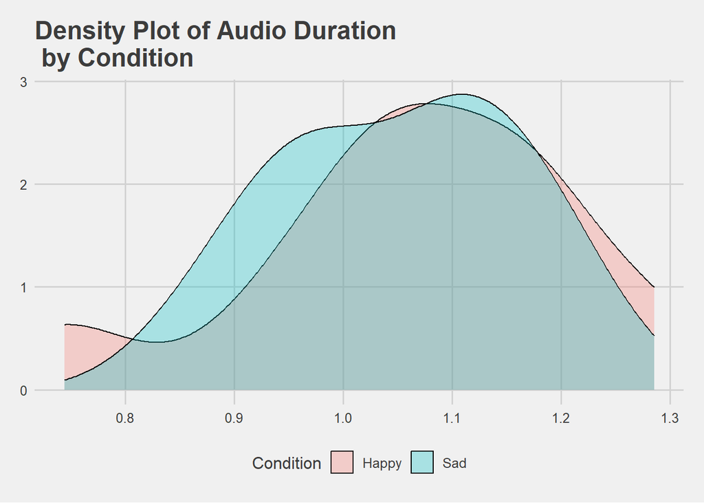

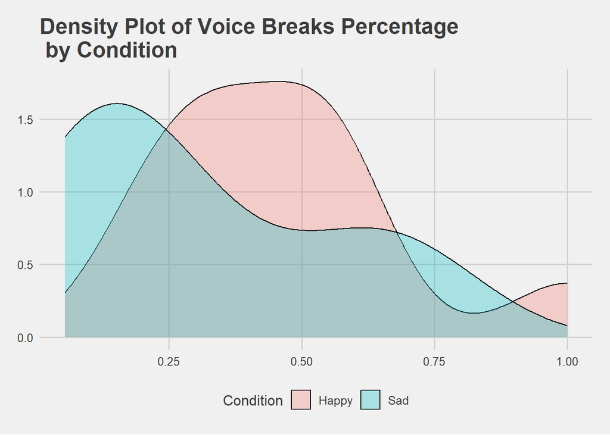

**Root Mean Square (RMS) of Amplitude envelope**

A Shapiro-Wilk test did not show a significant departure from normality for the RMS of Amplitude envelope measure, W(20) = 0.93, p = 0.17. Although, a Shapiro-Wilk test showed a significant departure from normality for Sad condition, W(10) = 0.82, p < .05.

**Loudness**

A Shapiro-Wilk test did not show a significant departure from normality for the loudness measure, W(20) = 0.93, p = 0.17. Although, a Shapiro-Wilk test showed a significant departure from normality for Sad condition, W(10) = 0.79, p < .05.

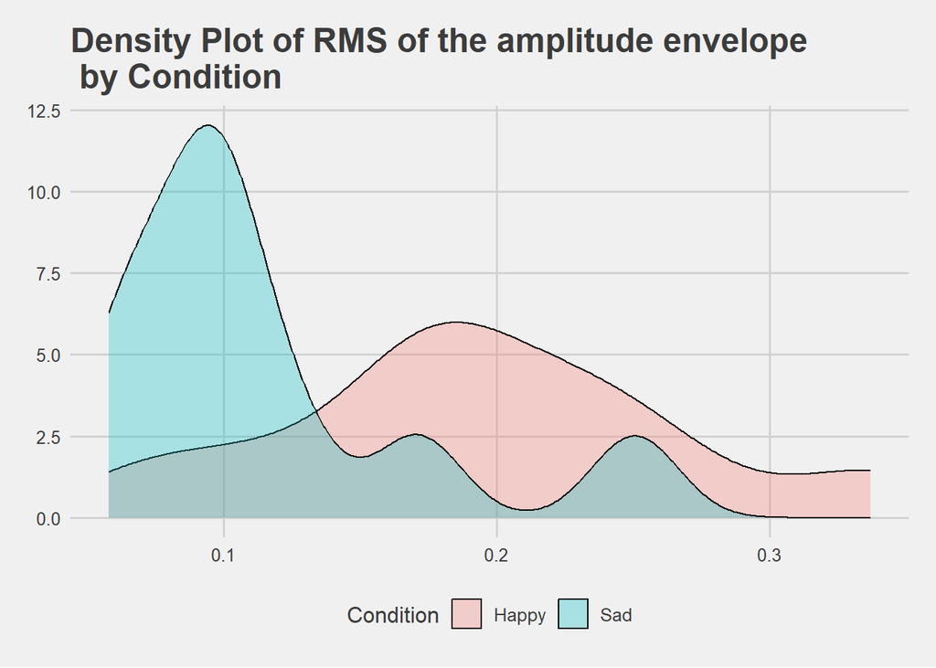

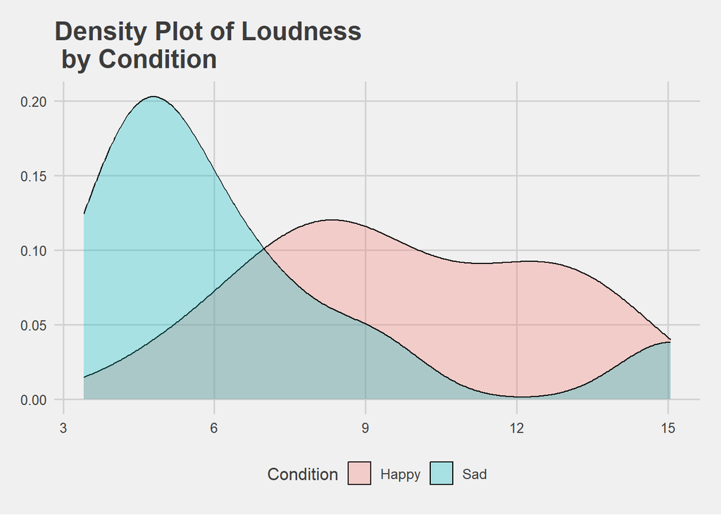

**Mean Fundamental Frequency (F0)**

A Shapiro-Wilk test showed a significant departure from normality for the average pitch measure, W(20) = 0.8, p < .01. Although, a Shapiro-Wilk test did not show a significant departure from normality for Happy condition, W(10) = 0.92, p = 0.36.

**Standard Deviation (sd) of F0**

A Shapiro-Wilk test showed a significant departure from normality for the pitch’s standard deviation measure, W(20) = 0.79, p < .01.

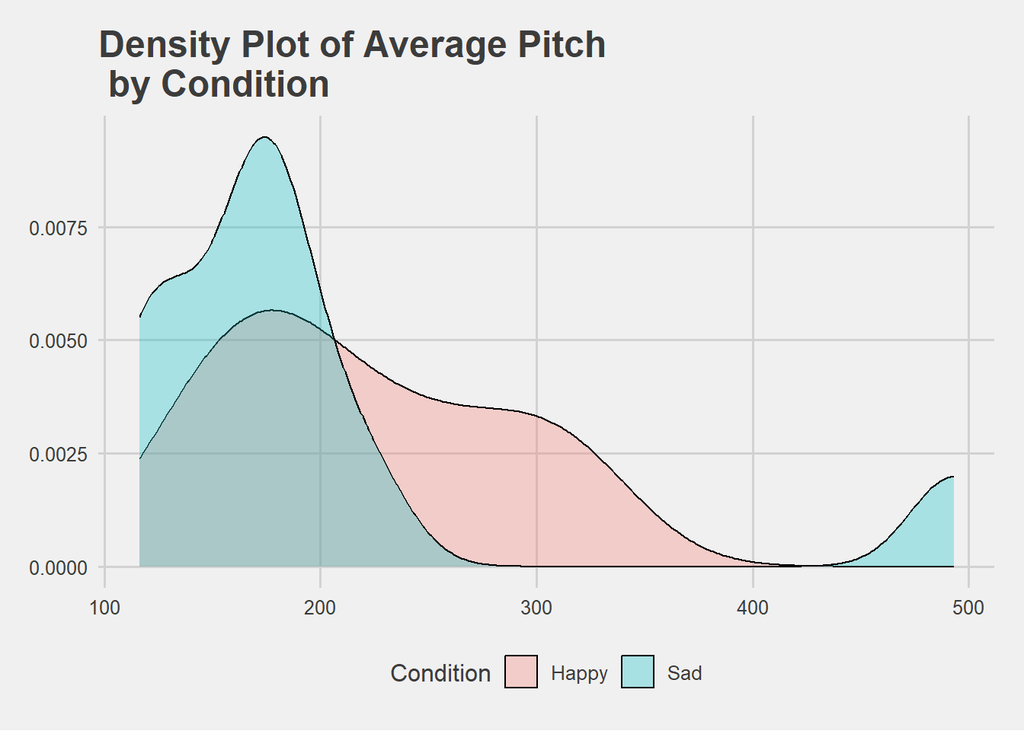

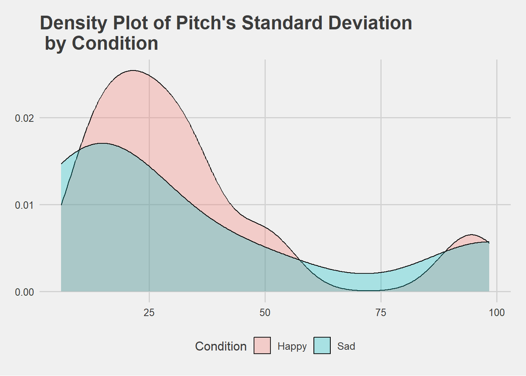

**Average Wiener Entropy**

A Shapiro-Wilk test did not show a significant departure from normality for the average Wiener entropy measure, W(20) = 0.95, p = 0.39.

**Average Harmonics-to-Noise Ratio**

A Shapiro-Wilk test did not show a significant departure from normality for the average Harmonics-to-Noise Ratio measure, W(20) = 0.96, p = 0.54.

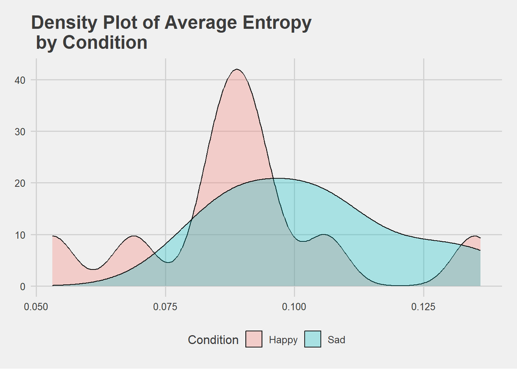

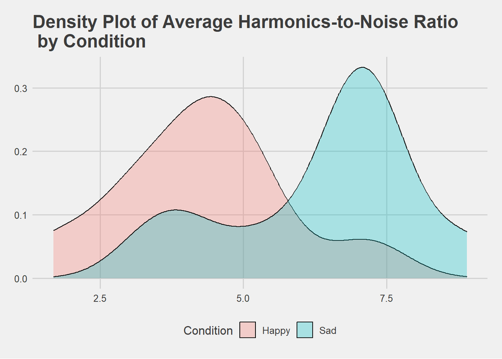

# Comparison Plots

**Duration**

**Voice Breaks Percentage**

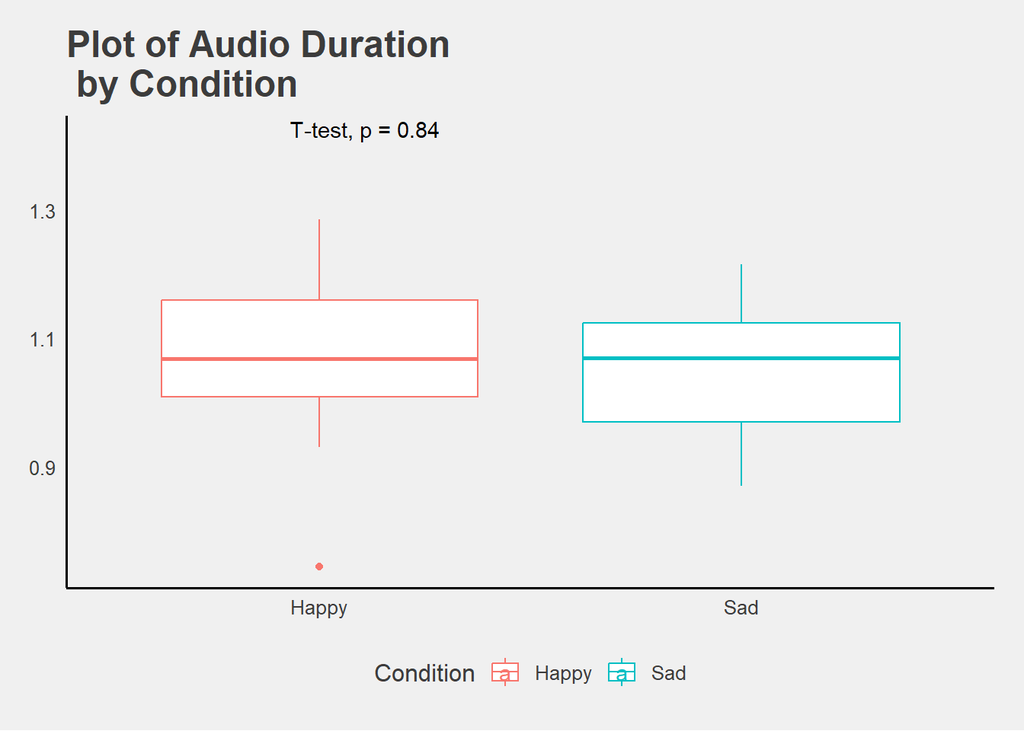

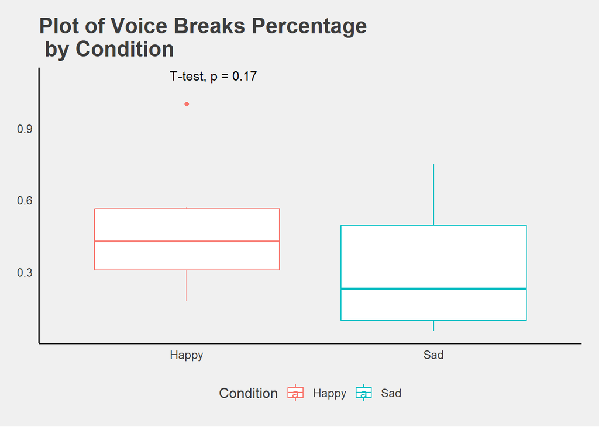

**RMS of the amplitude envelope**

A Wilcoxon Signed-Ranks Test indicated that RMS of the amplitude envelope mean rank was significantly higher for Happy condition (Mean Rank = 13.7) than Sad condition (Mean Rank = 7.3), Z = -2.44, p < .05

**Loudness**

A Wilcoxon Signed-Ranks Test indicated that loudness mean rank was significantly higher for Happy condition (Mean Rank = 13.6) than Sad condition (Mean Rank = 7.4), Z = -2.35, p < .05

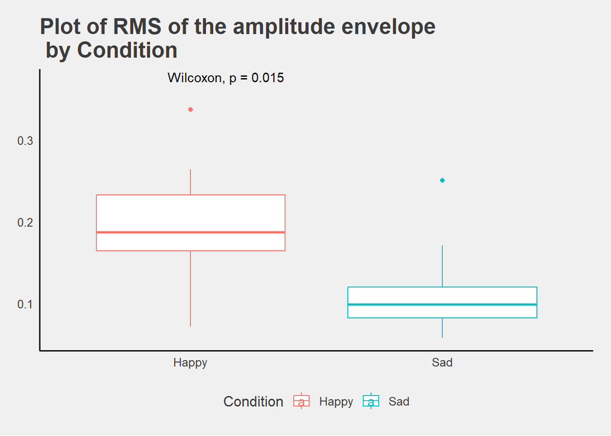

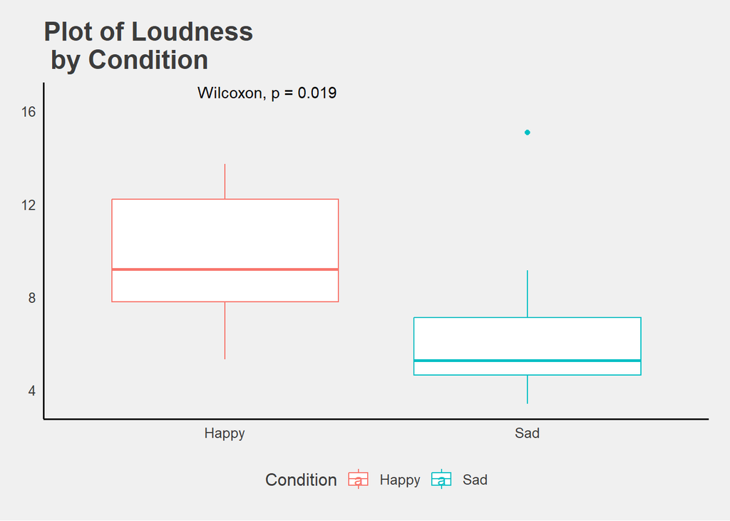

**Average Pitch**

A Wilcoxon Signed-Ranks Test did not show significant differences between Happy condition (Mean Rank = 12.8) and Sad condition (Mean Rank = 8.2), Z = -1.42, p = 0.16

**SD Pitch**

A Wilcoxon Signed-Ranks Test did not show significant differences between Happy condition (Mean Rank = 11.3) and Sad condition (Mean Rank = 9.7), Z = -0.2, p = 0.84

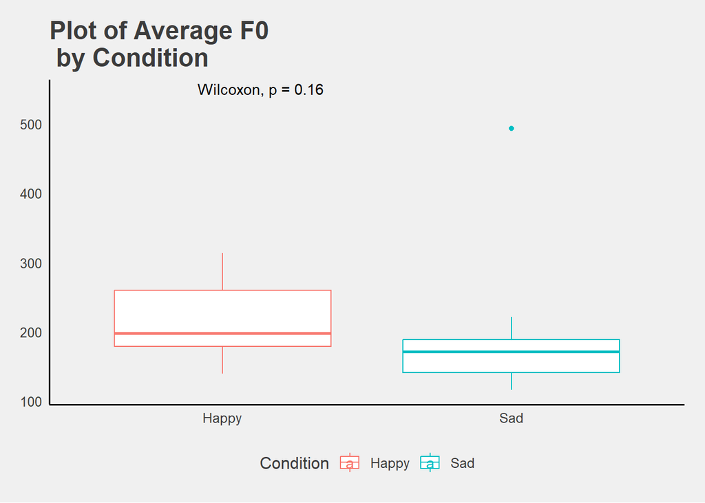

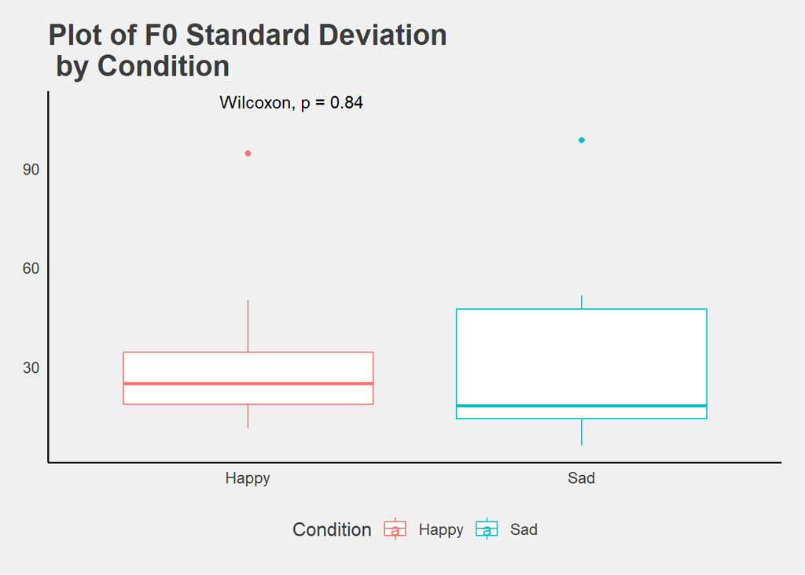

**Average Entropy**

**Average Harmonics-to-Noise Ratio**

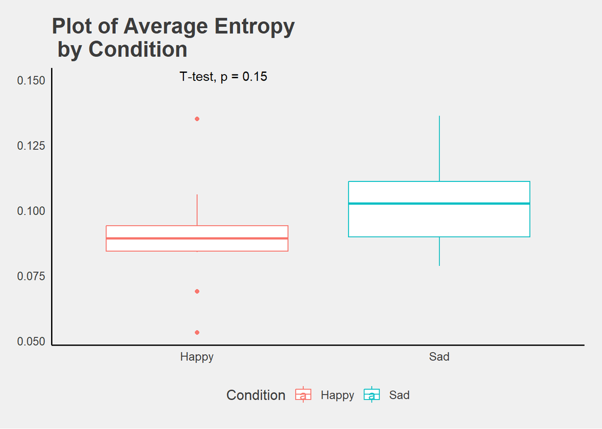

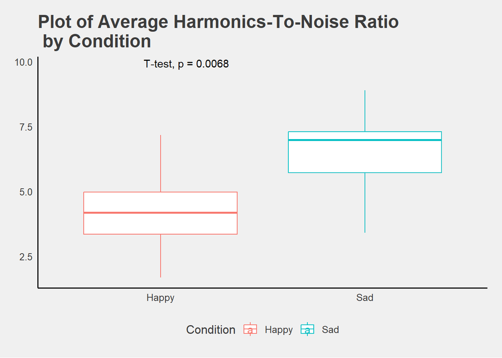

# Appendices

## Appendix A: General Data Information

Figure A1. Means and Standard Deviations of Audio Measures

|  | Duration | Voice Breaks Percentage | RMS of the amplitude envelope | Loudness | Avg. Pitch | Pitch SD | Avg Entropy | Avg HNR |
| --- | --- | --- | --- | --- | --- | --- | --- | --- |
| N | 20.00 | 20.00 | 20.00 | 20.00 | 20.00 | 20.00 | 20.00 | 20.00 |
| M | 1.06 | 0.39 | 0.15 | 8.15 | 206.67 | 35.07 | 0.10 | 5.35 |
| SD | 0.13 | 0.25 | 0.08 | 3.48 | 89.00 | 30.42 | 0.02 | 1.90 |

Note: N, M and SD are used to represent number of data points, mean and standard deviation, respectively.

Figure A2. Means and Standard Deviations of Audio Measures by Condition

| Condition | Duration N | Duration M | Duration SD | Voice Breaks Percentage N | Voice Breaks Percentage M | Voice Breaks Percentage SD | RMS of the amplitude envelope N | RMS of the amplitude envelope M | RMS of the amplitude envelope SD | Loudness N | Loudness M | Loudness SD | Avg. Pitch N | Avg. Pitch M | Avg. Pitch SD | Pitch SD N | Pitch SD M | Pitch SD SD | Avg Entropy N | Avg Entropy M | Avg Entropy SD | Avg HNR N | Avg HNR M | Avg HNR SD |
| --- | --- | --- | --- | --- | --- | --- | --- | --- | --- | --- | --- | --- | --- | --- | --- | --- | --- | --- | --- | --- | --- | --- | --- | --- |
| Happy | 10 | 1.06 | 0.15 | 10 | 0.46 | 0.23 | 10 | 0.20 | 0.07 | 10 | 9.77 | 2.82 | 10 | 217.96 | 64.40 | 10 | 33.93 | 25.68 | 10 | 0.09 | 0.02 | 10 | 4.26 | 1.50 |
| Sad | 10 | 1.05 | 0.11 | 10 | 0.31 | 0.25 | 10 | 0.11 | 0.06 | 10 | 6.53 | 3.44 | 10 | 196.50 | 109.14 | 10 | 36.09 | 35.52 | 10 | 0.10 | 0.02 | 10 | 6.43 | 1.66 |

Note: N, M and SD are used to represent number of data points, mean and standard deviation, respectively.

## Appendix B: Normality Tables

### Duration

Figure B1. Shapiro Wilk Normality Test for Duration by Condition

| Condition | N | W | p |
| --- | --- | --- | --- |
| General | 20 | .98 | .927 |
| Happy | 10 | .96 | .735 |
| Sad | 10 | .97 | .857 |

Note: * p < .05, ** p < .01, *** p < .001

### Voice Breaks Percentage

Figure B2. Shapiro Wilk Normality Test for Voice Breaks Percentage by Condition

| Condition | N | W | p |
| --- | --- | --- | --- |
| General | 20 | .94 | .279 |
| Happy | 10 | .89 | .185 |
| Sad | 10 | .87 | .095 |

Note: * p < .05, ** p < .01, *** p < .001

### RMS of the amplitude envelope

Figure B3. Shapiro Wilk Normality Test for RMS of the amplitude envelope by Condition

| Condition | N | W | p |
| --- | --- | --- | --- |
| General | 20 | .93 | .168 |
| Happy | 10 | .99 | .99 |
| Sad | 10 | .82 | .027 (*) |

Note: * p < .05, ** p < .01, *** p < .001

### Loudness

Figure B4. Shapiro Wilk Normality Test for Loudness by Condition

| Condition | N | W | p |
| --- | --- | --- | --- |
| General | 20 | .93 | .174 |
| Happy | 10 | .95 | .618 |
| Sad | 10 | .79 | .011 (*) |

Note: * p < .05, ** p < .01, *** p < .001

### Mean Pitch

Figure B5. Shapiro Wilk Normality Test for Average F0 by Condition

| Condition | N | W | p |
| --- | --- | --- | --- |
| General | 20 | .8 | .001 (**) |
| Happy | 10 | .92 | .363 |
| Sad | 10 | .65 | 0 (***) |

Note: * p < .05, ** p < .01, *** p < .001

### SD Pitch

Figure B6. Shapiro Wilk Normality Test for F0 Standard Deviation by Condition

| Condition | N | W | p |
| --- | --- | --- | --- |
| General | 20 | .79 | .001 (**) |
| Happy | 10 | .8 | .02 (*) |
| Sad | 10 | .77 | .007 (**) |

Note: * p < .05, ** p < .01, *** p < .001

### Entropy

Figure B7. Shapiro Wilk Normality Test for Average Entropy by Condition

| Condition | N | W | p |
| --- | --- | --- | --- |
| General | 20 | .95 | .393 |
| Happy | 10 | .93 | .46 |
| Sad | 10 | .95 | .659 |

Note: * p < .05, ** p < .01, *** p < .001

### HNR

Figure B8. Shapiro Wilk Normality Test for Average Harmonics-to-Noise Ratio by Condition

| Condition | N | W | p |
| --- | --- | --- | --- |
| General | 20 | .96 | .544 |
| Happy | 10 | .97 | .918 |
| Sad | 10 | .91 | .253 |

Note: * p < .05, ** p < .01, *** p < .001

### Duration

```
## No tables generated for t-test
```

### Voice Breaks Percentage

```
## [1] "No tables generated for t-test"
```

### RMS of the amplitude envelope

```
## [1] "No tables generated for t-test"
```

### Loudness

```
## [1] "No tables generated for t-test"
```

### Mean F0

```
## [1] "No tables generated for t-test"
```

### SD F0

```
## [1] "No tables generated for t-test"
```

### Mean Entropy

```
## [1] "No tables generated for t-test"
```

### Mean HNR

```
## [1] "No tables generated for t-test"
```